# Lab Assignment One: Exploring Table Data

## 1. Business Understanding

Spring is always the recruiting season for a company because there are a lot positions need to be filled in. While the company is trying to attract new employees, the company is also trying to figure out why the most skilled and experienced workers leaving prematurely.

Human Resources Analytics data has 14999 observations and 10 features, including both numerical and categorical features. It matches the Lab One requirement and is free to download at kaggle.com.

Through visualizing the features, exploring the features relationships, and other methods, we are able to help the management team to understand the most significant issues leading to the employees’ resignation.

From the analyzing, the management could have an idea what kind of employees are more likely to leave the company. In addition, the analyzing could help management team to adjust the policies (like reducing working hours and promoting salary) to keep and protect the most valuable employees.

Overall, the analytics also aid management team to identify employee’s best next step and help the most skilled and experienced employees to have a better career.

========================================================================

Dataset: Human Resources Analytics URL: https://www.kaggle.com/ludobenistant/hr-analytics

Question Of Interest: Which employees will leave next?

## 2. Data Understanding

### 2.1 Data Description

```python
# load the human-resourse dataset
import pandas as pd
import numpy as np
import warnings
warnings.filterwarnings("ignore")

df = pd.read_csv('C://Users/anonymous/Desktop/HR_comma_sep.csv')

# replace the column name of 'sales' to 'department'
df = df.rename(columns = {'Work_accident': 'work_accident', 'sales': 'department'})

# replace salary level to numrical indicator
df.salary.replace(to_replace = ['low', 'medium', 'high'],
                 value = range(1,4), inplace = True)
df.head()
```

|  | satisfaction_level | last_evaluation | number_project | average_montly_hours | time_spend_company | work_accident | left | promotion_last_5years | department | salary |
| --- | --- | --- | --- | --- | --- | --- | --- | --- | --- | --- |
| 0 | 0.38 | 0.53 | 2 | 157 | 3 | 0 | 1 | 0 | sales | 1 |
| 1 | 0.80 | 0.86 | 5 | 262 | 6 | 0 | 1 | 0 | sales | 2 |
| 2 | 0.11 | 0.88 | 7 | 272 | 4 | 0 | 1 | 0 | sales | 2 |
| 3 | 0.72 | 0.87 | 5 | 223 | 5 | 0 | 1 | 0 | sales | 1 |
| 4 | 0.37 | 0.52 | 2 | 159 | 3 | 0 | 1 | 0 | sales | 1 |

Salary was origianlly in "low", "medium", "high". And this feature was replaced by "1", "2", and "3" to represent "low", "medium", and "high" respectively.

```python
# find the data type
print(df.info())
```

```
<class 'pandas.core.frame.DataFrame'>
RangeIndex: 14999 entries, 0 to 14998
Data columns (total 10 columns):
satisfaction_level       14999 non-null float64
last_evaluation          14999 non-null float64
number_project           14999 non-null int64
average_montly_hours     14999 non-null int64
time_spend_company       14999 non-null int64
work_accident            14999 non-null int64
left                     14999 non-null int64
promotion_last_5years    14999 non-null int64
department               14999 non-null object
salary                   14999 non-null int64
dtypes: float64(2), int64(7), object(1)
memory usage: 1.1+ MB
None
```

Based on the dataframe information, no missing values are found in the dataset as there are 14999 entries in each feature (14999 rows in the data).

But if there were missing values in the dataset, we could use mean or median imputation for the numerical features and mode for the categorical features.

Also, the data description shows no 0 values, or werid numbers, under 'satisfaction_level', 'last_evaluation', 'number_project', 'average_montly_hours'. Therefore, it also can't be missing value in this data.

```python
# find the data summary
df.describe()
```

|  | satisfaction_level | last_evaluation | number_project | average_montly_hours | time_spend_company | work_accident | left | promotion_last_5years | salary |
| --- | --- | --- | --- | --- | --- | --- | --- | --- | --- |
| count | 14999.000000 | 14999.000000 | 14999.000000 | 14999.000000 | 14999.000000 | 14999.000000 | 14999.000000 | 14999.000000 | 14999.000000 |
| mean | 0.612834 | 0.716102 | 3.803054 | 201.050337 | 3.498233 | 0.144610 | 0.238083 | 0.021268 | 1.594706 |
| std | 0.248631 | 0.171169 | 1.232592 | 49.943099 | 1.460136 | 0.351719 | 0.425924 | 0.144281 | 0.637183 |
| min | 0.090000 | 0.360000 | 2.000000 | 96.000000 | 2.000000 | 0.000000 | 0.000000 | 0.000000 | 1.000000 |
| 25% | 0.440000 | 0.560000 | 3.000000 | 156.000000 | 3.000000 | 0.000000 | 0.000000 | 0.000000 | 1.000000 |
| 50% | 0.640000 | 0.720000 | 4.000000 | 200.000000 | 3.000000 | 0.000000 | 0.000000 | 0.000000 | 2.000000 |
| 75% | 0.820000 | 0.870000 | 5.000000 | 245.000000 | 4.000000 | 0.000000 | 0.000000 | 0.000000 | 2.000000 |
| max | 1.000000 | 1.000000 | 7.000000 | 310.000000 | 10.000000 | 1.000000 | 1.000000 | 1.000000 | 3.000000 |

```python
# create a data description table
data_des = pd.DataFrame()

data_des['Features'] = df.columns
data_des['Description'] = ['level of satisfaction', 'evaluation of employee performance',
                          'number of projects completed while ata work', 'average monthly hours at workplace',
                          'number of years spent in the company', 'whether the employee had a workplace accident',
                          'whether the employee left the workplace', 'whether the employee was promoted in the last five years',
                          'department in which they work for', 'relative level of salary']
data_des['Scales'] = ['ratio'] * 5 + ['norminal'] * 4 +['ordinal']
data_des['Discrete\Continuous'] = ['continuous'] * 2 + ['discrete'] + \
                                  ['continuous'] + ['discrete'] * 6
data_des['Range'] = ['0.09 - 1.00', '0.36 - 1.00', '2 - 7', '96 - 310',
                    '2 - 10'] + ['0: No; 1: Yes'] * 3 + [repr(set(df.department))] + \
                    ['1: low; 2: medium; 3: high']

data_des
```

|  | Features | Description | Scales | Discrete\Continuous | Range |
| --- | --- | --- | --- | --- | --- |
| 0 | satisfaction_level | level of satisfaction | ratio | continuous | 0.09 - 1.00 |
| 1 | last_evaluation | evaluation of employee performance | ratio | continuous | 0.36 - 1.00 |
| 2 | number_project | number of projects completed while ata work | ratio | discrete | 2 - 7 |
| 3 | average_montly_hours | average monthly hours at workplace | ratio | continuous | 96 - 310 |
| 4 | time_spend_company | number of years spent in the company | ratio | discrete | 2 - 10 |
| 5 | work_accident | whether the employee had a workplace accident | norminal | discrete | 0: No; 1: Yes |
| 6 | left | whether the employee left the workplace | norminal | discrete | 0: No; 1: Yes |
| 7 | promotion_last_5years | whether the employee was promoted in the last ... | norminal | discrete | 0: No; 1: Yes |
| 8 | department | department in which they work for | norminal | discrete | {'technical', 'product_mng', 'accounting', 'sa... |
| 9 | salary | relative level of salary | ordinal | discrete | 1: low; 2: medium; 3: high |

The table above shows the features description, sacles, and range.

### 2.2 Data Quality

Let's clean the dataset a little before moving on.

First, all attributes are useful in the analyses. And as it stated before, there is no missing value in the dataset.

We should then check whether duplicate data exists.

```python
# find the duplicate instances
idx = df.duplicated()

# find the number of duplicate (not first show)
len(df[idx])
```

```
3008
```

```python
# df[idx]
```

Through the duplicates check, it shows there are 3008 observations duplicated values in the dataset. And from the result of df[idx], the majority of the duplicated are the last 3000 observations. We had a heated discussion and decided to keep these in the dataset for two reasons. First, we don't have obivious evidence to prove it's true duplicates becasue no ID information showed in the dataset; secondely, we assumed the oversampling method (like bootstrap) probably was performed by the data editor because the promation rate was extremely low, about 0.021.

## 3. Data Visualization

### 3.1 Data Exploration

```python
import matplotlib.pyplot as plt
import warnings
warnings.simplefilter('ignore', DeprecationWarning)
%matplotlib inline
```

#### 3.1.1 Resignation Rate by Department

```python
# Lets aggregate by department and count the resignation rate
df_grouped_department = df.groupby(by='department')
for val,grp in df_grouped_department:
    print('There were',len(grp),'people working in',val +'.')

print('---------------------------------------')
print('The Resignation Rate:')
print(df_grouped_department.left.sum() / df_grouped_department.left.count())
```

```
There were 1227 people working in IT.
There were 787 people working in RandD.
There were 767 people working in accounting.
There were 739 people working in hr.
There were 630 people working in management.
There were 858 people working in marketing.
There were 902 people working in product_mng.
There were 4140 people working in sales.
There were 2229 people working in support.
There were 2720 people working in technical.
---------------------------------------
The Resignation Rate:
department
IT             0.222494
RandD          0.153748
accounting     0.265971
hr             0.290934
management     0.144444
marketing      0.236597
product_mng    0.219512
sales          0.244928
support        0.248991
technical      0.256250
Name: left, dtype: float64
```

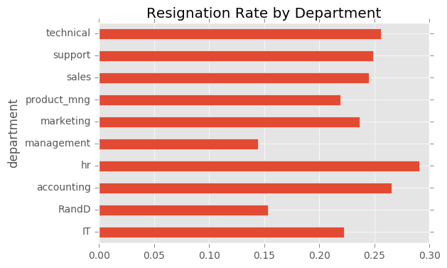

```python
# Start by just plotting what we previsously grouped!
plt.style.use('ggplot')

resignation_rate = df_grouped_department.left.sum() / df_grouped_department.left.count()
ax = resignation_rate.plot(kind='barh')
plt.title('Resignation Rate by Department')
```

The "Resignation Rate by Department" shows the employee left rate in each department. The table shows HR department has the highest resignation rate in the company, almost 0.30; and the lowest resignation rate is from the lowest management, about 0.14. Accounting is the second highest resignation rate, about 0.26. The top two resignation rate are from HR and accounting department. The decision makers should pay more attention on these two departments.

#### 3.1.2 Resignation Rate by Salary

```python
# Lets aggregate by class and count survival rates
df_grouped_salary = df.groupby(by='salary')
for val,grp in df_grouped_salary:
    print('There were',len(grp),'people working in salary group',val,'.')
print('---------------------------------------')
print('Note: group 1: low salary; group 2: medium salary; group 3: high salary.')
print('---------------------------------------')
print(df_grouped_salary.left.sum() / df_grouped_salary.left.count())
```

```
There were 7316 people working in salary group 1 .
There were 6446 people working in salary group 2 .
There were 1237 people working in salary group 3 .
---------------------------------------
Note: group 1: low salary; group 2: medium salary; group 3: high salary.
---------------------------------------
salary
1    0.296884
2    0.204313
3    0.066289
Name: left, dtype: float64
```

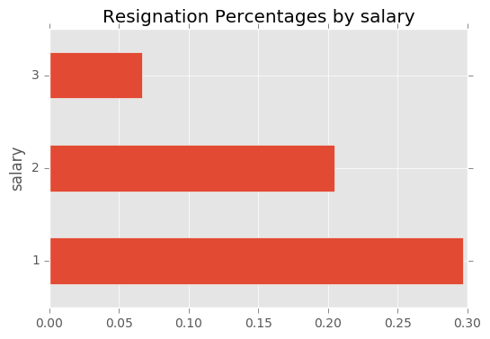

```python
plt.style.use('ggplot')

resignation_rate = df_grouped_salary.left.sum() / df_grouped_salary.left.count()
ax = resignation_rate.plot(kind='barh')
plt.title('Resignation Percentages by salary')
```

Note: group 1: low salary; group 2: medium salary; group 3: high salary.

Note2: The x-axis range is 0 to 0.3.

The low salary employee has the highest resignation percentage, almost reaching 0.30. This bar-chart matches the common sense that high salary employees have more stable positions and more likely to stay in the company.

#### 3.1.3 Resignation Rate by Promotion_last_five_years and Salary

```
left                          False  True
salary promotion_last_5years
1      0                       5092   2158
       1                         52     14
2      0                       4953   1312
       1                        176      5
3      0                       1083     82
       1                         72      0
```

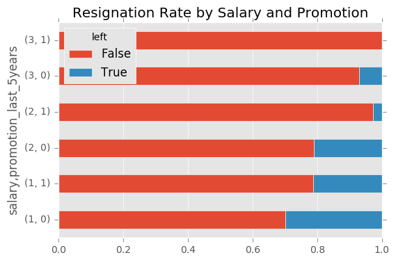

```python
# the cross tab operator provides an easy way to get these numbers
left = pd.crosstab([df['salary'],
                        df['promotion_last_5years']],
                       df.left.astype(bool))
print(left)

left_rate = left.div(left.sum(1).astype(float),
                             axis=0) # normalize the value
left_rate.plot(kind='barh',
                   stacked=True)
plt.title('Resignation Rate by Salary and Promotion')
```

Note: (salary, promotion_last_5years) in the y-axis represents the different levels in salary and wether promoted in last five years.

As we can see, non-promoted employees always have higher rate than promoted employees in the different salary levels, especially for the medium salary group. The blue part (resignation rate) in non-promoted employees of mediuam salary is significantly greater than the promoted ones of medium salary.

#### 3.1.4 Resignation Rate by Department and Salary

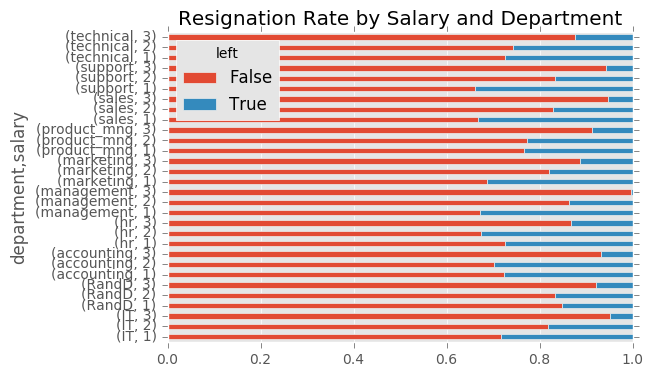

```python
# cross rearrangement by department, salary, and left
df_cross = pd.crosstab([df['department'],
                        df['salary']],
                       df.left.astype(bool))

resignation_rate = df_cross.div(df_cross.sum(1).astype(float), axis=0)

# plot resignation_rate
resignation_rate.plot(kind='barh', stacked=True)
plt.title('Resignation Rate by Salary and Department')
```

#### 3.1.5 Distributions of Continuous Features

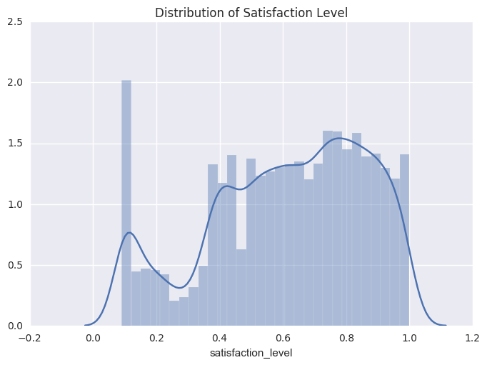

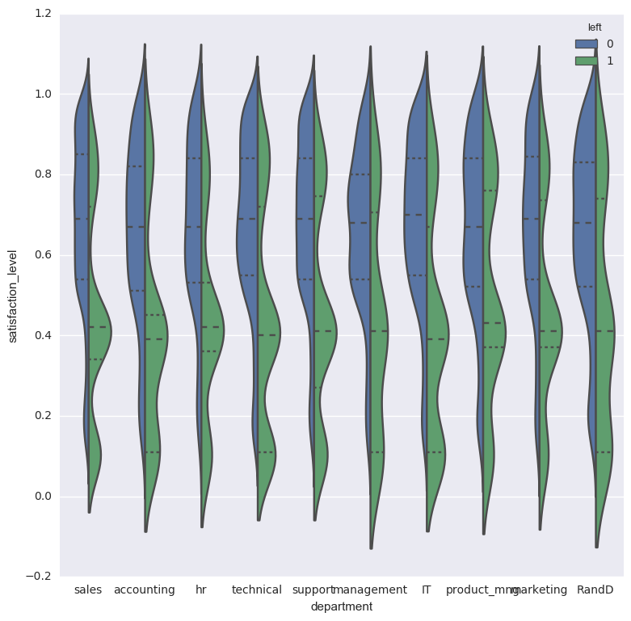

```python
import seaborn as sns
cmap = sns.diverging_palette(220, 10, as_cmap=True)

sns.distplot(df.satisfaction_level)
plt.title('Distribution of Satisfaction Level')
f, ax = plt.subplots(figsize=(9, 9))

sns.violinplot(x="department", y="satisfaction_level", hue="left", data=df,
               split=True, inner="quart")
```

According to the violin plot, different departments have similar spread and shape of satisfication level. In the same departemt, the distributions of people who stayed are approximately normal, but the distributions of people who left are multimodal.

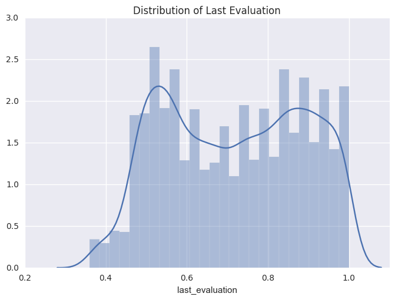

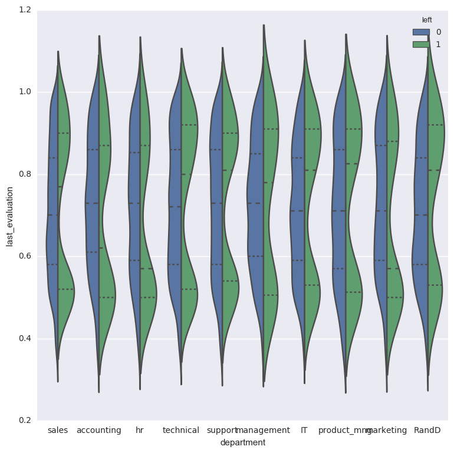

```python
sns.distplot(df.last_evaluation)
plt.title('Distribution of Last Evaluation')

f, ax = plt.subplots(figsize=(9, 9))

sns.violinplot(x="department", y="last_evaluation", hue="left", data=df,
               split=True, inner="quart")
```

Distribution of Last Evaluation suggests it is a bimodal distribution and it suggests different departments have similar spread and shape of evaluation last time. In the same departemt, the distributions of people who stayed are approximately normal, but the distributions of people who left are bimodal.

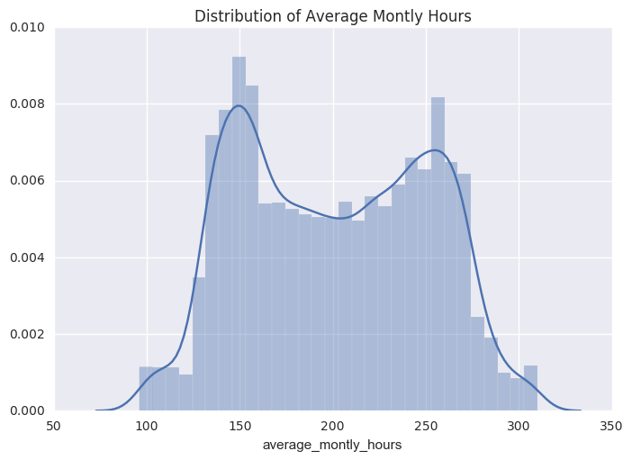

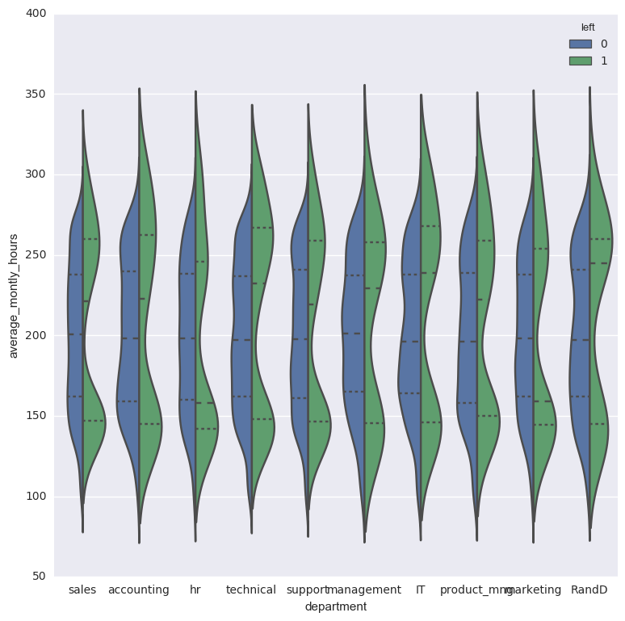

```python
sns.distplot(df.average_montly_hours)
plt.title('Distribution of Average Montly Hours')

f, ax = plt.subplots(figsize=(9, 9))

sns.violinplot(x="department", y="average_montly_hours", hue="left", data=df,
               split=True, inner="quart")
```

#### 3.1.6 Feature Discretization

```
left                  False  True
eva_level hour_level
eva_low   hour_low     3244   1572
          hour_media   1594     32
          hour_high    1085     77
eva_media hour_low     1747     55
          hour_media   1114    205
          hour_high     843    756
eva_high  hour_low      877     29
          hour_media    538    301
          hour_high     386    544
```

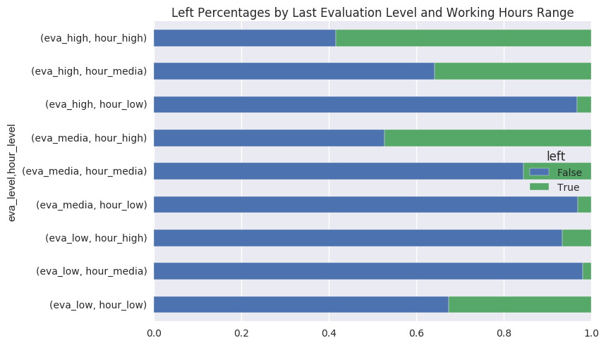

```python
df['hour_level'] = pd.cut(df.average_montly_hours,[0,200,245,320],2, labels=['hour_low','hour_media','hour_high'])
df['eva_level'] = pd.cut(df.last_evaluation,[0,0.72,0.9,1],2, labels=['eva_low','eva_media','eva_high'])
#df.hour_level.describe()

left = pd.crosstab([df['eva_level'],
                    df['hour_level']],
                    df.left.astype(bool))
print(left)

left_rate = left.div(left.sum(1).astype(float),
                             axis=0) # normalize the value

# print survival_rate
left_rate.plot(kind='barh',
                   stacked=True)
plt.title('Left Percentages by Last Evaluation Level and Working Hours Range')
```

We use approximately 25th,50th,75th percntile to cut the continues variables, "last_evaluation" and " average_montly_hours". Then we generate a bar chart.

### 3.2 Data Relationship Exploration

#### 3.2.1 Correaltion Matrix

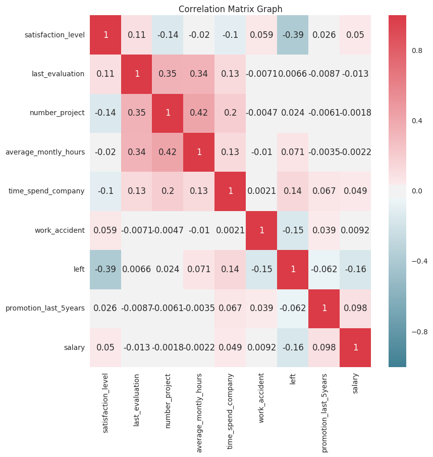

```python
# plot the correlation matrix using seaborn
sns.set(style="darkgrid") # one of the many styles to plot using

f, ax = plt.subplots(figsize=(9, 9))

sns.heatmap(df.corr(), cmap=cmap, annot=True)

f.tight_layout()
plt.title('Correlation Matrix Graph')
```

According to the correlation table, "last_evaluation", "number_project","average_monthly_hours", and "time_spend_company" have positive correlation with each other. Through our table, we are focusing on left, it shows that left & satisfaction and left & salary have comparatively strong negative correlation with each other, that means the higher the satisfaction level (or salary ) people have, the less chance they leave the company. left & time_speed_company has postive correlation with each other, that means the higher the time spent in company people have, the higher chance they leave the company.

3.2.2 Scatter plots except for department

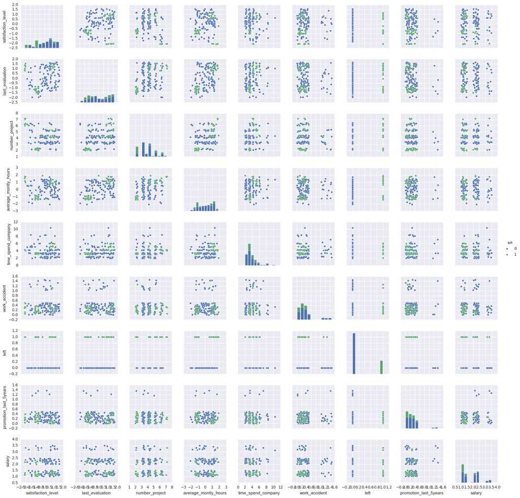

```python
from sklearn import preprocessing
df_scaled = df
df_scaled[[0,1,3]] = preprocessing.scale(df_scaled[[0,1,3]])

df_sample = df_scaled.sample(frac=0.01, replace=False)

df_sample_jitter = df_sample.copy()
df_sample_jitter[df.columns[[2,4,5,7,9]]] = df_sample_jitter[df.columns[[2,4,5,7,9]]].values + np.random.rand(len(df_sample_jitter),5)/2
sns.pairplot(df_sample_jitter, hue="left", size=2)
```

From the matrix of the scatter plots, we can see that the above features are not very good classifiers for our target feature 'left'. Therefore, we are to transform the features into two principle components by using PCA.

## 4. Dimensionality Reduction

```python
from sklearn.decomposition.pca import PCA
from sklearn import preprocessing
df_scaled = df.copy()
df_scaled[[0,1,2,3,4]] = preprocessing.scale(df_scaled[[0,1,2,3,4]])
for col in ['salary','department','work_accident','hour_level','eva_level','left','promotion_last_5years']:
    if col in df_scaled:
        del df_scaled[col]
df_scaled=pd.DataFrame(df_scaled)
df_scaled.head()
```

|  | satisfaction_level | last_evaluation | number_project | average_montly_hours | time_spend_company |
| --- | --- | --- | --- | --- | --- |
| 0 | -0.936495 | -1.087275 | -1.462863 | -0.882040 | -0.341235 |
| 1 | 0.752814 | 0.840707 | 0.971113 | 1.220423 | 1.713436 |
| 2 | -2.022479 | 0.957554 | 2.593763 | 1.420657 | 0.343655 |
| 3 | 0.431041 | 0.899131 | 0.971113 | 0.439508 | 1.028546 |
| 4 | -0.976716 | -1.145699 | -1.462863 | -0.841993 | -0.341235 |

```python
from sklearn.decomposition import PCA

X = df_scaled
y = df.left
target_names='left'

pca = PCA(n_components=2)
X_pca = pca.fit(X).transform(X) # fit data and then transform it

# print the components

print ('pca:', pca.components_)
```

```
pca: [[ 0.08688429 -0.50740199 -0.57907693 -0.54928085 -0.31297732]
 [-0.83127011 -0.36996992  0.11257602 -0.12457178  0.37936893]]
```

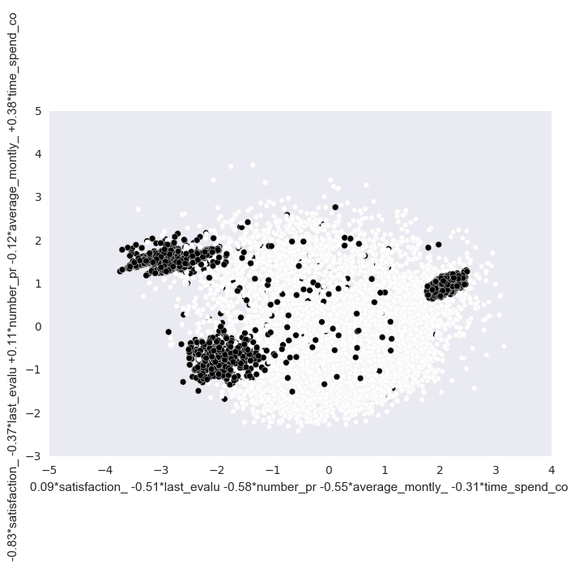

```python
def get_feature_names_from_weights(weights, names):
    tmp_array = []
    for comp in weights:
        tmp_string = ''
        for fidx,f in enumerate(names):
            if fidx>0 and comp[fidx]>=0:
                tmp_string+='+'
            tmp_string += '%.2f*%s ' % (comp[fidx],f[:-5])
        tmp_array.append(tmp_string)
    return tmp_array

# now let's get to the Data Analytics!
pca_weight_strings = get_feature_names_from_weights(pca.components_, df_scaled.columns)

# create some pandas dataframes from the transformed outputs
df_pca = pd.DataFrame(X_pca,columns=[pca_weight_strings])

from pandas.tools.plotting import scatter_plot

# scatter plot the output, with the names created from the weights
ax = scatter_plot(df_pca, pca_weight_strings[0], pca_weight_strings[1], c=y, s=(y+2)*10)
```

After Principle Component Analysis, we reduce the data dimension from 5 to 2, visualizing the two dimension plot above, we found their are 3 clusters apearing in the graph, and they have distinguished boundary. If there were a point falling in the high-density black-point area, it's more likely to be classified as left. But we concerned that it might be too many white points closing to the high-density black-point area. For the clear visulization, we decided to take a subset from the orignial dataset and produce another two dimentional plot.

```python
# manipulated from Sebastian Raschka Example (your book!)
# also from hi blog here: http://sebastianraschka.com/Articles/2015_pca_in_3_steps.html


def plot_explained_variance(pca):
    import plotly
    from plotly.graph_objs import Scatter, Marker, Layout, XAxis, YAxis, Bar, Line
    plotly.offline.init_notebook_mode() # run at the start of every notebook

    explained_var = pca.explained_variance_ratio_
    cum_var_exp = np.cumsum(explained_var)

    plotly.offline.iplot({
        "data": [Bar(y=explained_var, name='individual explained variance'),
                 Scatter(y=cum_var_exp, name='cumulative explained variance')
            ],
        "layout": Layout(xaxis=XAxis(title='Principal components'), yaxis=YAxis(title='Explained variance ratio'))
    })


pca = PCA(n_components=4)
X_pca = pca.fit(X)
plot_explained_variance(pca)
```

[interactive chart not shown]

According to the plot of explained variation, we can see that the first two components we get after Principle Components Analysis explains about 60% of original 5 ratio features in the huamn resource data.

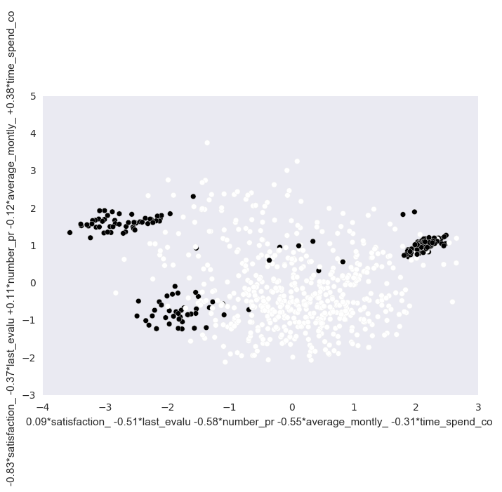

```python
df_sample = df_pca.sample(frac=0.05, replace=False)
ax = scatter_plot(df_sample, pca_weight_strings[0], pca_weight_strings[1], c=y[df_sample.index.values], s=(y+2)*10)
```

We sample randomly 5% of the observations from the data set to have better visualization after PCA. The result is approximately matching the previous two dimentional plot. We observed high density black-point on the right part, and the white-point closing to this area is low. If there were a point falling in this area, it has more possibility to classified as left.

## Reference

Kaggle. Human Resources Analytics. https://www.kaggle.com/ludobenistant/hr-analytics (Accessed 02-01-2017)